# hw-02

Jason Xu (S2867957)

2026-10-28

```r
strava_runs <- read_csv("data/strava_runs.csv")
data_5k_10k <- strava_runs %>%
  mutate(
    event = case_when(
      distance..m. > 4998 & distance..m. < 5015  ~ "5k",
      distance..m. > 9998 & distance..m. < 10015 ~ "10k",
      TRUE ~ NA_character_
    )
  ) %>%
  filter(!is.na(event))
```

## Exercise 1

When you fill the missing part, remove the # symbol before running the code chunk and eval=FALSE

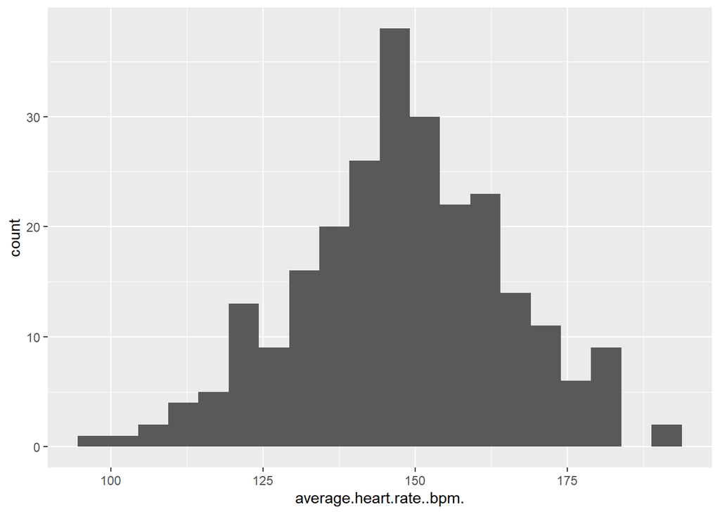

```r
data_5k_10k %>%
  filter(gender=="M") %>%
  filter(!is.na(average.heart.rate..bpm.)) %>%
  ggplot(aes(x = average.heart.rate..bpm.)) +
  geom_histogram(bins = 20)
```

```r
data_5k_10k %>%
  filter(gender == "M") %>%
  summarise(
    mean_hr = mean(average.heart.rate..bpm., na.rm = TRUE),
    median_hr = median(average.heart.rate..bpm., na.rm = TRUE),
    sd_hr = sd(average.heart.rate..bpm., na.rm = TRUE)
  )
```

```
## # A tibble: 1 × 3
##   mean_hr median_hr sd_hr
##     <dbl>     <dbl> <dbl>
## 1    148.      148.  17.2
```

This histogram is unimodal and with a main peak around 145-150 bpm. And most of the runs have an average heart rate between approximately 130 and 170 bpm. And there are only few observations at the lower and upper ends. This means the average heart rates in these male runners’ 5k and 10k runs are concentrated in a central region but with some variability.The mean and median are both approximately 148 bpm, with a standard deviation of 17.2 bpm.

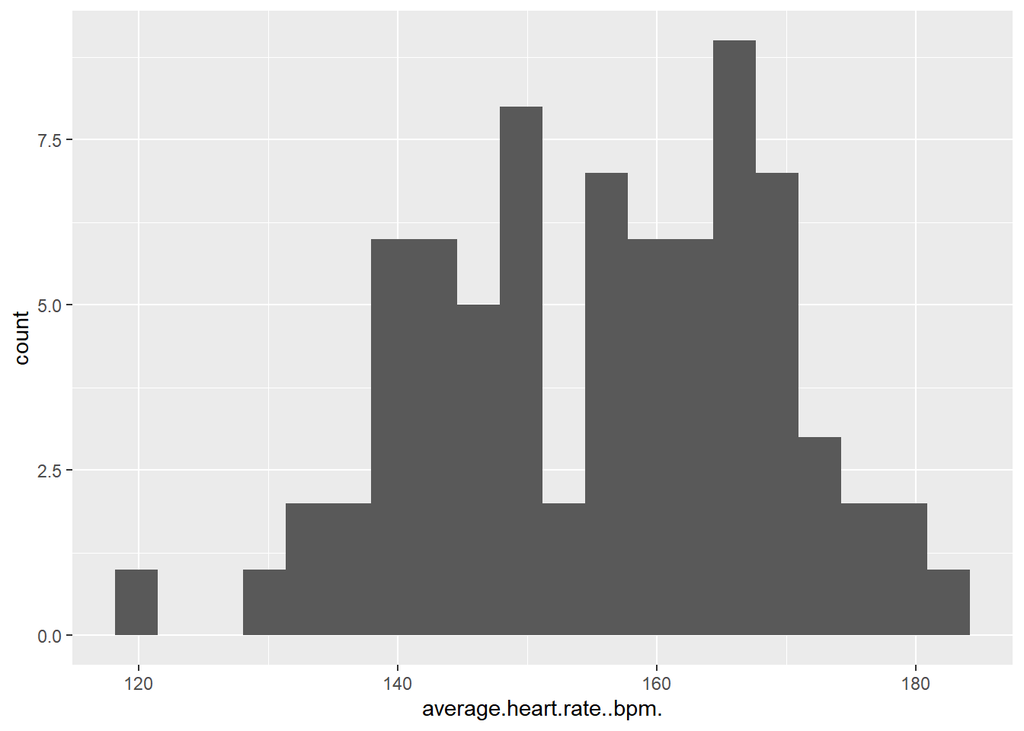

```r
data_5k_10k %>%
  filter(gender=="F") %>%
  filter(!is.na(average.heart.rate..bpm.)) %>%
  ggplot(aes(x = average.heart.rate..bpm.)) +
  geom_histogram(bins = 20)
```

This histogram is bimodal and with two main peak. The first one is around 145-150 bpm and the other one is around 165-170 bpm. And most of the female runs have an average heart rate between approximately 135-170 bpm. And there are only few observations at the lower and upper ends, which means the average heart rates in these female runners’ 5k and 10 k runs are concentrated in a central region. And compared with the male histogram, the female histogram is less smooth and have two peaks rather than one clear central peak. And the average heart rates in female runs appear slightly higher than in male runs.

## Exercise 2

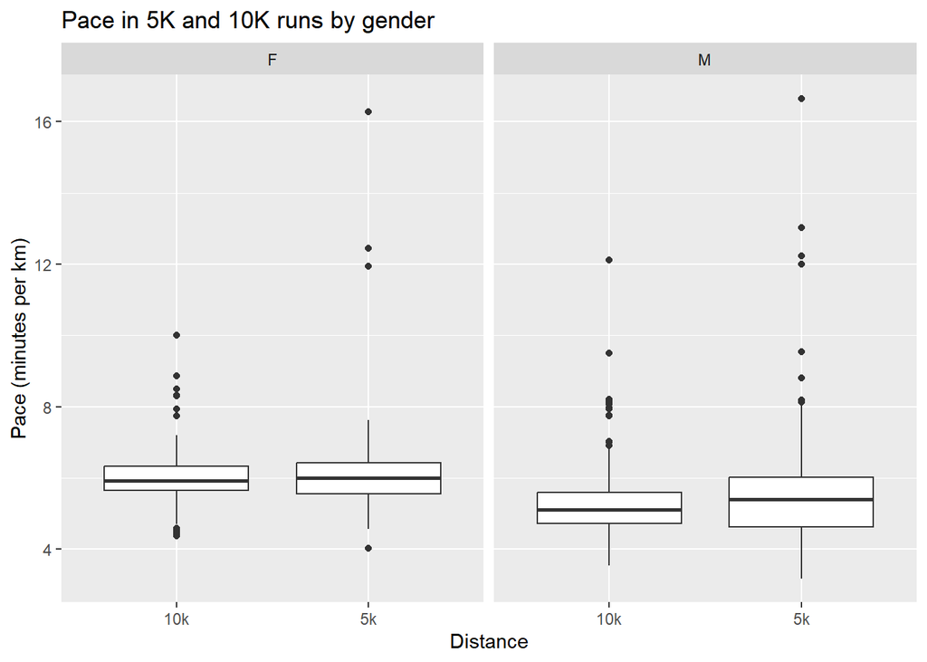

```r
Pace_data<-data_5k_10k %>%
filter(gender=="M" | gender=="F")%>%
mutate(
pace=(elapsed.time..s./60)/(distance..m./1000)
)
Pace_data %>%
  ggplot(aes(x=event,y=pace))+
  geom_boxplot()+
  facet_wrap(~gender)+
  labs(
  title = "Pace in 5K and 10K runs by gender",
  x = "Distance",
  y = "Pace (minutes per km)"
)
```

In this dataset, male runners have a lower median pace than female runners for both 5K and 10K although small part of the distributions are overlap. And for male runners, the median pace of 10K is lower than 5K, but the female median paces are similar for both distances. And all groups have some high pace outliers.

## Exercise 3

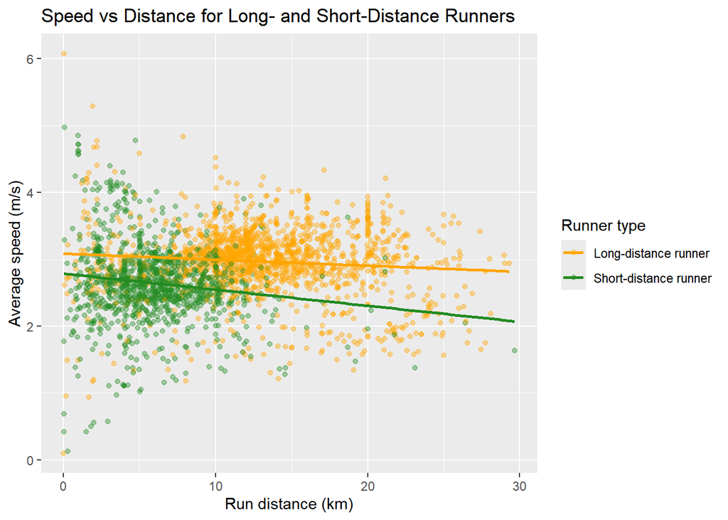

```r
runner_data<-strava_runs %>%
  group_by(athlete)%>%
  mutate(
    mean_distance_km=mean(distance..m.,na.rm=TRUE)/1000
  )%>%
  ungroup()%>%
  filter(mean_distance_km > 13 | mean_distance_km < 7) %>%
  mutate(
    runner_type=ifelse(mean_distance_km>13,"Long-distance runner","Short-distance runner"),
    distance_km = distance..m. / 1000,
    speed = distance..m. / elapsed.time..s.
  )
runner_data %>%
  ggplot(aes(x = distance_km,y = speed,color = runner_type)) +
  geom_point(alpha = 0.4) +
  geom_smooth(method = "lm", se = FALSE) +
  scale_color_manual(
    values = c("Long-distance runner" = "orange","Short-distance runner" = "forestgreen")
  ) +
   labs(
    title = "Speed vs Distance for Long- and Short-Distance Runners",
    x = "Run distance (km)",
    y = "Average speed (m/s)",
    color = "Runner type"
  )
```

The plot shows that the speed of both groups tends to decrease as the distance increases. And the line for long-distance runners is flatter, but the line for short-distance runners drops more clearly. This suggests that long-distance runners may maintain their speed better over longer distances, which supports the idea in the question. And there is overlap between the two groups, so not every runner follows the same pattern.

## Exercise 4

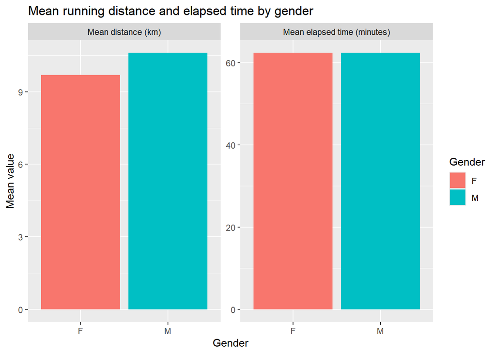

```r
gender_data <- strava_runs %>%
  filter(!is.na(gender)) %>%
  group_by(gender) %>%
  summarise(
    mean_distance = mean(distance..m., na.rm = TRUE) / 1000,
    mean_time = mean(elapsed.time..s., na.rm = TRUE) / 60
  )

gender_long <- gender_data %>%
  pivot_longer(
    cols = c(mean_distance, mean_time),
    names_to = "measure",
    values_to = "value"
  )

gender_long %>%
  ggplot(aes(x = gender, y = value, fill = gender)) +
  geom_col() +
  facet_wrap(
    ~measure,
    scales = "free_y",
    labeller = as_labeller(c(
      mean_distance = "Mean distance (km)",
      mean_time = "Mean elapsed time (minutes)"
    ))
  ) +
  labs(
    title = "Mean running distance and elapsed time by gender",
    x = "Gender",
    y = "Mean value",
    fill = "Gender"
  )
```

In this dataset, male runners have a slightly higher mean running distance than female runners. And the mean elapsed times are very similar for both genders, at just over 60 minutes. This means that male runners cover a longer distance on average while spending about the same amount of time running.